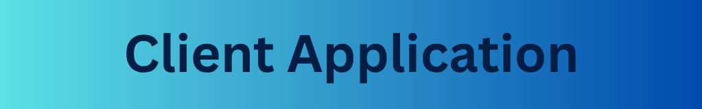

# Client B Case Study

## Published Company Statistics in 2024

| Company Overview |
| --- |
| Number of Employees: 2,000 |
| Net Turnover: €550.5 Million |
| EU Net Turnover: €450 Million |
| Total Assets: €450 Million |

*All monetary values were converted from British Pound GBP to Euros using the 2024 average exchange rate of 1.811 (Exchange-rates.org, 2024) and then slightly altered for anonymity.

## Application of Case Study to the “Stop the Clock” Proposal:

**Approved Changes to the CSRD:**

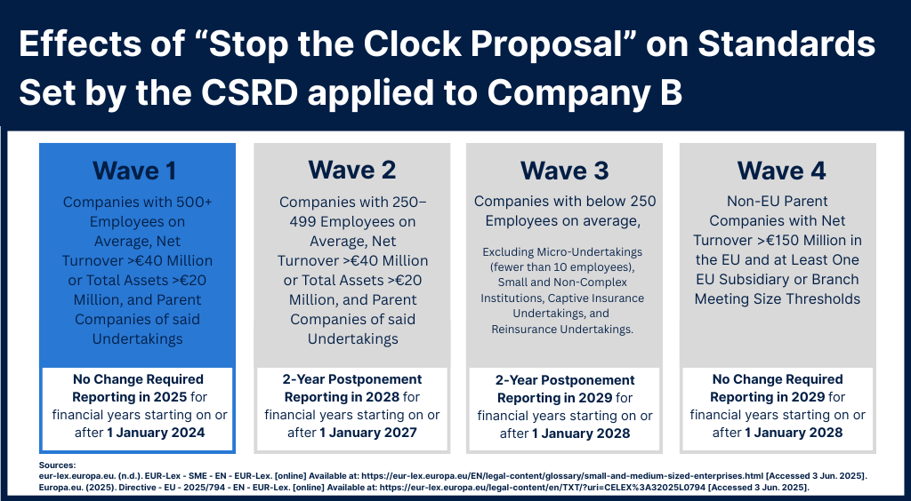

Company B is classified as a Wave 1 company, as it significantly exceeds both thresholds: employing over 500 people and reporting a net turnover of more than €40 million. As the company is classified as Wave 1, it is not affected by the proposal and is still required to report in 2025 for financial years beginning on or after January 1, 2024.

**Approved Changes to the CSDDD:**

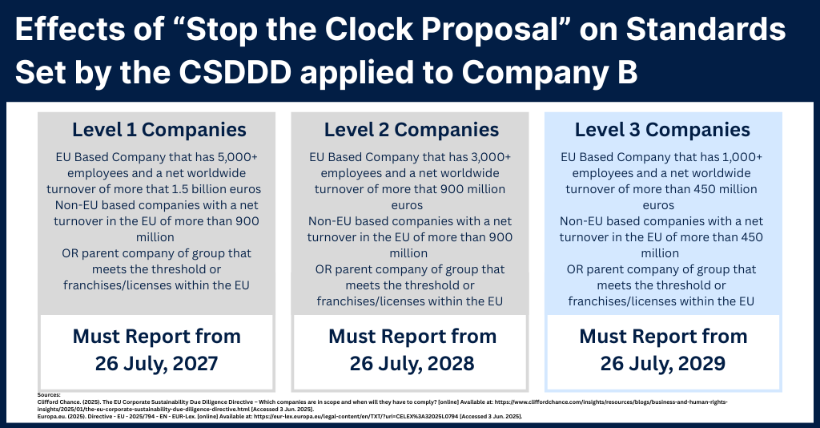

Though, Company B likely does not meet the threshold for meeting the CSDDD the EU Net Turnover has been altered to provide an example of effects of the proposed changes to the CSDDD. Company B must report from 26th July, 2029 according to the Stop the Clock Proposal.

## Application of Case Study to Proposed Changes:

**Proposed Changes to the CSRD:**

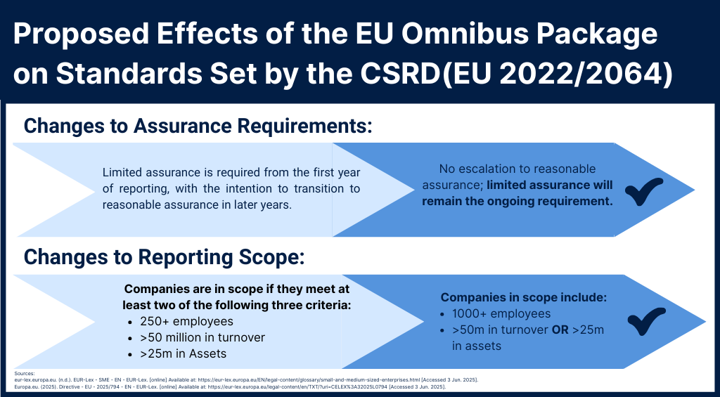

As Company B is a Wave 1 company under the CSRD and already required to report, it will not experience any changes to the reporting content or timeline. The only change is confirmation that assurance requirements will not be increase to reasonable assurance.

**Proposed Changes to the CSDDD:**

Proposed Changes to the CSDDD applied to Client B

Harmonization

- Improved accessibility of complaint mechanisms and strengthed remediation pathways
- Potentially stricter measures placed by Member States

Stakeholder Definition

- Stakeholder scope now excludes general public interest groups or indirect stakeholders

Focus on Direct Business Partners

Mandatory Termination of Relationships

- Terminating relationships no longer required
- Companies should instead suspend the relationship and attempt remediation.

Less Frequent Monitoring

- Company is now only required to assess due diligence effectiveness every five years (instead of every year), unless urgent issues arise.

The proposed changes to the CSDDD aim to reduce administrative burden on companies. It is clear that these changes will achieve this goal while still holding companies responsible for due dilligence reporting.

**Proposed Changes to CBAM:**

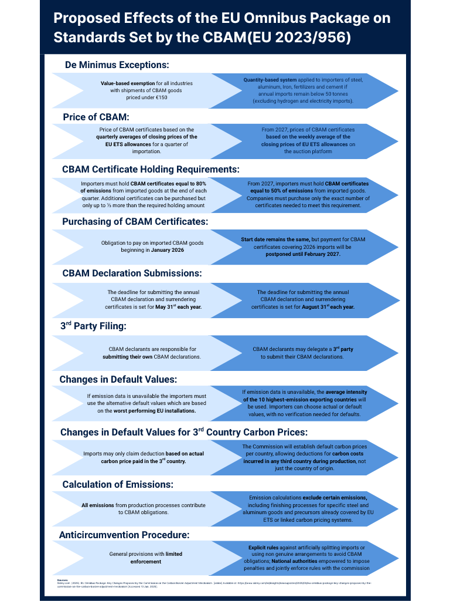

The proposed changes to CBAM aim to reduce the administrative burden on importers and encourage trade within the EU. Under the revised de minimis exemption, if a company imports fewer than 50 tonnes of goods, CBAM allowances would not apply. However, such a low volume is unlikely given current production levels.

The option to hire a third party to submit CBAM declarations may also present a business opportunity. The updated default values will reduce the cost of certificates when emissions data is unavailable, making a lack of emission data less punitive. Emission calculations will now exclude certain finishing processes in the steel industry, which may effect certain products in production. Finally, the new anti-circumvention clause increases exposure for companies attempting to exploit the system and deters efforts to avoid CBAM obligations.